# “Real Men Don’t Need Therapy?”

## A Computational Text Analysis of Mental Health Discourse in Red Pill Youtube Communities

### Text Analysis and Natural Language Processing

#### May 2026

# Executive Summary

The findings show that red pill communities don't just keep quiet when it comes to therapy; they also have a lot of arguments about therapy—specifically, how males and females can talk about their mental health and the role that societal standards of masculinity play in shaping discourse. This study shows the potential usefulness of using Natural Language Processing (NLP) methodologies to discover and explore hidden (or latent) ideological trends in Internet communications.

# 1. Introduction

The increase in the visibility of the online 'manosphere' and 'red pill' communities has led to the development of discourse around topics like masculinity, self-improvement, relationships and emotional vulnerability. This increase in visibility has resulted in both an increase in academic and public scrutiny of these communities and an increase in concerns about the spread of misogynistic content, radicalization or anti-feminist discourse within those spaces. However, there has been much less attention paid to exploring ways in which discussions around therapy, emotional vulnerability and mental health are constructed through discourse in those spaces.

Before we delve too far into the project lets define the manosphere and red pill content as these are words that will be used frequently throughout this study. Academically, Botto and Gottzen (2023) have describes the manosphere as a loosely connected misogynistic online movement that is particulary attractive to young men who share this Red Pill neoconservative ideology that pushes notions of gender and sexuality, selective evolutionary psychology that tend to support male supremacy. In this "manosphere" we are speaking about a collection of varied blogs, websites and online discourse forums that promote masculinity, misogyny, and the opposition of feminism. This includes communities like men's rights activists (MRAs), incels (involuntary celibates), men going their own way (MGTOW) and random pick-up artists.

In the center of the manosphere is the concept of "red pill" content. The red pill ideology is rooted in the belief that as a consumer of the content, you become awake to the reality that the entire world is built for the comfort of women over men, it borrows the premise of the metaphor seen on The Matrix that suggests that if you disagree with the content then you remain deceived (UN Women, 2026). Van Valkenburgh (2021) has distinctly describes these red pill spaces or communities as "forums wherein heterosexual men discuss evolutionary psychology and economic theories, integrating neoliberal discourses into an ideology of male self-improvement and supremacy".

Hence, this study goes beyond analysing the way we engage on the internet. Men's mental health has always been a big conversation within society, with men being less likely to seek professional help when facing mental health difficulties whereas they account for approximately 75% of all suicide deaths in multiple countries (Möller-Leimkühler, 2002; Seidler et al., 2016). Research has shown over numerous occasions that masculinity and the judgement of how men are meant to behave, has been a significant barrier to their ability to seek the assistance they need (Addis & Mahalik, 2003). In these "red pill" and "manosphere" communities have began to gain popularity and major traction, understanding how these groups talk (or construct) about therapy and mental health will become increasingly important to the success of our public mental health efforts. These online communities then create or perpetuate the stigma against seeking mental health care which then builds a negative perspective towards mens willingness to seek assistance.

This research study seeks to help fill this gap by examining how mental health, therapy, emotional vulnerability and help-seeking behaviours are constructed through discourse within comment sections of red pill-related YouTube video content. Specifically, the project will examine how norms surrounding masculinity influence attitudes towards the use of therapy, emotional expression and psychological support as it is being constructed through discourse in online comment sections related to red pill video content. The current research study will also compare constructions of therapy, emotional vulnerability, and mental health across gendered groups and will explore whether constructions of mental health contribute to the ongoing reproduction of mental health stigma.

This study acknowledges that comment sections may include 'bots' and/or automated accounts that can amplify certain messages or narratives in comment sections and this could impact how members of the community express themselves in the discussions and contribute to the overall discourse even if they are acting as individuals rather than through inorganic means.

The purpose of the project is to apply both quantitative research methods using Natural Language Processing (NLP) methods and critical social theory perspectives to understand these patterns. To do this, the project uses various computational text analysis techniques(Natural Language Processing) in Python such as keyword frequency analysis, sentiment analysis, collocation analysis, etc., to identify linguistic and thematic patterns within YouTube Comments that were collected from some of popular Red Pill related Videos.

Through the use of computational techniques in the analysis of online discourse about these topics, this project provides insight into how gender norms, emotional vulnerability, and perceptions of therapists are interrelated within digital spaces.

# 2. Research Questions and Hypotheses

**Main Research Question:**

• How is mental health help-seeking discursively constructed in red pill online spaces, and how does this construction differ by gender?

**Sub-questions:**

• The frequency at which therapy appears to be mentioned in relation to sentiment.

• How the terms "male" and "female" are used with respect to mental health.

• How much is the use of self-improvement language replacing the language of seeking professional assistance.

**Hypothesis:**

• H1: Mentions of therapy in red pill comment sections are associated with negative or dismissive sentiment.

• H2: Male mental health is framed through narratives of self-discipline and hierarchy rather than vulnerability

• H3: Female mental health struggles are delegitimised or moralised in the discourse.

• H4: Self-improvement language (e.g., "gym," "grind," "high-value," "dominance") appears more frequently than professional help-seeking language.

# 3. Data Collection and Corpus Construction

A dataset was created by collecting comments made on 10 popular YouTube videos about red pill content, created by red pill content creators and videos with commentary on red pill content from creators from around the world. The total number of comments collected from the 10 videos is 13075 comments, obtained via the YouTube Data API.

[output not shown]

The original corpus was filtered to only have comments that align with at least 1 of the keywords that are related to mental health, as seen below. The result of the sub-corpus showed 1785 comments which is approximately 13.6% of the total collected and represented a targeted set of comments that will later undergo an analysis that is more mental health focused.

## Keywords:

*Help-seeking:* "therapy", "therapist", "counseling", "help", "support"

*Mental health conditions:* "depression", "depressed", "anxiety", "anxious", "suicide", "suicidal", "mental health"

*Emotional language:* "lonely", "alone", "feelings", "emotion"

*Masculinity / ideology:* "masculinity", "alpha male", "gender roles", "self-improvement", "submissive woman"

*Stigma / framing:* "weak", "weak mind"

# 4. Data Cleaning and Preprocessing

```python
from googleapiclient.discovery import build
import os, pandas as pd

API_KEY = os.environ.get('YOUTUBE_API_KEY', "YOUR_KEY_HERE")
youtube = build('youtube', 'v3', developerKey=API_KEY)

def get_comments(video_id, max_comments=1500):
    comments = []
    request = youtube.commentThreads().list(
        part='snippet', videoId=video_id,
        maxResults=100, textFormat='plainText'
    )
    while request and len(comments) < max_comments:
        response = request.execute()
        for item in response['items']:
            c = item['snippet']['topLevelComment']['snippet']
            comments.append({'video_id': video_id,
                             'text': c['textDisplay'],
                             'likes': c['likeCount'],
                             'date': c['publishedAt'],
                            "reply_count": item ["snippet"]["totalReplyCount"]
                            })
        request = youtube.commentThreads().list_next(request, response)
    return comments



# Proposed videos
video_ids = [
    "FaP_7hq6mmU",
    "6LDP_SyswNk",
    "79q5Pbaekds",
    "xO5AB1gCnRw",
    "VI6XWGKvUrE",
    "NX2ep5fCJZ8",
    "uMlRMAZ0lB0",
    "4nWcEtUV4do",
    "5yyWlp6sTv0",
    "dCCmdUNGukY"
]

all_comments = []

for vid in video_ids:
    print(f"Collecting from {vid}...")
    comments = get_comments(vid, max_comments=1500)
    print(f"Collected {len(comments)} comments")
    all_comments.extend(comments)

df = pd.DataFrame(all_comments)
df.to_csv("all_comments.csv", index=False)

print("Total comments collected:", len(all_comments))
df.shape
```

```
Collected 1500 comments
Collected 1500 comments
Collected 1500 comments
Collected 1500 comments
Collected 1500 comments
Collected 1500 comments
Collected 1500 comments
Collected 309 comments
Collected 766 comments
Collected 1500 comments
Total comments collected: 13075
```

```
(13075, 5)
```

```python
import re

def clean_text(text):
    text = text.lower()
    text = re.sub(r"http\S+", "", text)
    text = re.sub(r"[^a-z\s]", "", text)
    text = re.sub(r"\s+", " ", text).strip()
    return text

df["clean_text"] = df["text"].apply(clean_text)
```

```python
import re

mental_health_keywords = [
    # Help-seeking
    "therapy", "therapist", "counseling", "help", "support",

    # Mental health conditions
    "depression", "depressed", "anxiety", "anxious",
    "suicide", "suicidal", "mental health",

    # Emotional language
    "lonely", "alone", "feelings", "emotion",

    # Masculinity / ideology
    "masculinity", "alpha male", "gender roles",
    "self-improvement", "submissive woman",

    # Stigma / framing
    "weak", "weak mind"
]

# Regex pattern
pattern = r"|".join(re.escape(keyword) for keyword in mental_health_keywords)

# Filtering
mh_df = df[df["clean_text"].str.contains(pattern, case=False, na=False)]

print("Mental health-related comments:", len(mh_df))
mh_df.head()
```

```
Mental health-related comments: 1785
```

|  | video_id | text | likes | date | reply_count | clean_text |
| --- | --- | --- | --- | --- | --- | --- |
| 22 | FaP_7hq6mmU | I disagree that social media isn't helping to ... | 0 | 2025-05-21T07:02:45Z | 1 | i disagree that social media isnt helping to r... |
| 44 | FaP_7hq6mmU | No, women spend hours on online dating sites b... | 0 | 2025-01-10T04:22:13Z | 0 | no women spend hours on online dating sites be... |
| 73 | FaP_7hq6mmU | These fucking dudes are delusional and also du... | 0 | 2024-10-30T20:52:42Z | 0 | these fucking dudes are delusional and also du... |
| 122 | FaP_7hq6mmU | This is why this section of the manosphere is ... | 0 | 2024-07-23T10:11:03Z | 1 | this is why this section of the manosphere is ... |
| 227 | FaP_7hq6mmU | For some reason most girls sadly tend to be cl... | 0 | 2024-01-17T02:45:34Z | 1 | for some reason most girls sadly tend to be cl... |

```python
mh_df = df[df["clean_text"].str.contains(pattern, case=False, na=False)]
```

```python
def label_category(text):
    text = text.lower()
    categories = []

    # Therapy / help-seeking
    if any(word in text for word in ["therapy", "therapist", "counseling", "help", "support"]):
        categories.append("therapy")

    # Mental health conditions
    if any(word in text for word in ["depression", "depressed", "anxiety", "suicide", "suicidal"]):
        categories.append("mental_health_condition")

    # Masculinity / ideology
    if any(word in text for word in [
        "alpha", "alpha male", "masculinity",
        "gender roles", "self-improvement", "submissive"
    ]):
        categories.append("masculinity_discourse")

    # Emotional language
    if any(word in text for word in ["feelings", "emotion", "lonely", "alone"]):
        categories.append("emotional_expression")

    if not categories:
        categories.append("other")

    return categories


mh_df["category"] = mh_df["clean_text"].apply(label_category)

print("Mental health comments:", len(mh_df))
mh_df.head()
```

```
Mental health comments: 1785
```

|  | video_id | text | likes | date | reply_count | clean_text | category |
| --- | --- | --- | --- | --- | --- | --- | --- |
| 22 | FaP_7hq6mmU | I disagree that social media isn't helping to ... | 0 | 2025-05-21T07:02:45Z | 1 | i disagree that social media isnt helping to r... | [therapy] |
| 44 | FaP_7hq6mmU | No, women spend hours on online dating sites b... | 0 | 2025-01-10T04:22:13Z | 0 | no women spend hours on online dating sites be... | [other] |
| 73 | FaP_7hq6mmU | These fucking dudes are delusional and also du... | 0 | 2024-10-30T20:52:42Z | 0 | these fucking dudes are delusional and also du... | [masculinity_discourse] |
| 122 | FaP_7hq6mmU | This is why this section of the manosphere is ... | 0 | 2024-07-23T10:11:03Z | 1 | this is why this section of the manosphere is ... | [therapy] |
| 227 | FaP_7hq6mmU | For some reason most girls sadly tend to be cl... | 0 | 2024-01-17T02:45:34Z | 1 | for some reason most girls sadly tend to be cl... | [other] |

```python
mh_df.to_csv("mental_health_comments.csv", index=False)
```

```python
therapy_words = ["therapy", "therapist", "counseling", "help", "support"]

self_improvement_words = [
    "gym", "grind", "discipline", "money",
    "success", "alpha", "strong", "self improvement"
]
```

# 5. Descriptive Statistics

This section summarizes the kinds of language that can be found in the mental health corpus by looking at how many times certain types of therapeutic language is used compared to self-improvement related terms. By using this comparison, it is possible to form a conclusion on whether people who are interested in appearing to be optimally functioning have more discussions about seeking professional help or optimising themselves. With this analysis we are able to provide an initial qualitative basis to assist in evaluating Hypothesis 4 and forming a contextual framework for sentiment and collocation analyses.

Descriptive statistics are used to identify the major themes, help establish baseline corpus patterns, and provide the contextual framework for later performing sentiment and collocation analyses.

```python
import re

def count_mentions(texts, keywords):
    total_count = 0

    for text in texts:
        for word in keywords:
            matches = re.findall(rf"\b{word}\b", text)
            total_count += len(matches)

    return total_count


therapy_words = ['therapy', 'therapist', 'counseling', 'help', 'support']
self_improvement_words = ['gym', 'grind', 'discipline', 'money', 'success',
                          'alpha', 'strong', 'self improvement']

def count_mentions(texts, keywords):
    return sum(len(re.findall(rf'\b{w}\b', t)) for t in texts for w in keywords)

therapy_mentions = count_mentions(mh_df['clean_text'], therapy_words)
self_mentions    = count_mentions(mh_df['clean_text'], self_improvement_words)
print('Therapy-related mentions:', therapy_mentions)
print('Self-improvement mentions:', self_mentions)
```

```
Therapy-related mentions: 1119
Self-improvement mentions: 752
```

Exploration of the frequency analysis is able to reveal that therapy-related terms and language appered more often that self-improvement terms through the filtered corpus.

The majority of mentions in the corpus described around 59.8% of all mental-health related mentions (1119 out of 1871 total mentions), compared to the other approximate 40.2% of the mentions used to describe self-improvement language (752 out of 1871 total mentions). It is important to note that these figures are not mutually exclusive because a single comment can contain both therapeutic and self-improvement language. This speaks to the first hypothesis that the mention of therapy is under a negative or dismissive sentiment, where it is assumed that most conversations within these red-pill spaces are focused around self-improvement.

The fact that therapy is mentioned frequently does not convey whether those references are made positively or negatively. The high amount of appearances may also show that there is much criticism, skepticism, or ongoing debate about therapy, instead of therapy being seen as being good for getting professional assistance. We currently are unable to ascertain if the conversations being had are dismissive or negative but we are able to see that there is plenty of conversation around therapy in these comment sections.

```python
def count_comments_with_word(texts, keywords):
    comment_count = 0

    for text in texts:
        if any(
            re.search(rf"\b{word}\b", text)
            for word in keywords
        ):
            comment_count += 1

    return comment_count

therapy_comments = count_comments_with_word(
    mh_df["clean_text"],
    therapy_words
)

self_comments = count_comments_with_word(
    mh_df["clean_text"],
    self_improvement_words
)

print("Comments mentioning therapy:", therapy_comments)
print("Comments mentioning self-improvement:", self_comments)
```

```
Comments mentioning therapy: 733
Comments mentioning self-improvement: 244
```

```python
total_comments = len(mh_df)

therapy_percentage = (
    therapy_comments / total_comments
) * 100

self_percentage = (
    self_comments / total_comments
) * 100

print(f"Therapy-related comments: {therapy_percentage:.2f}%")
print(f"Self-improvement comments: {self_percentage:.2f}%")
```

```
Therapy-related comments: 41.06%
Self-improvement comments: 13.67%
```

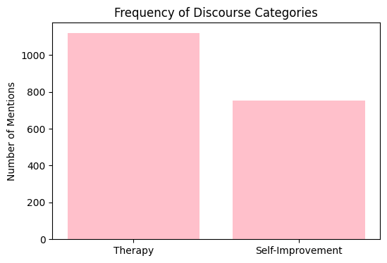

```python
import matplotlib.pyplot as plt

categories = [
    "Therapy",
    "Self-Improvement"
]

counts = [
    therapy_mentions,
    self_mentions
]

plt.figure(figsize=(6,4))
plt.bar(categories, counts, color="#ffc0cb")

plt.title("Frequency of Discourse Categories")
plt.ylabel("Number of Mentions")

plt.show()
```

The bar chart illustrates how often discussions use language relevant to therapy and self-improvement. The data demonstrate that there are much higher numbers of therapy conversations than self-improvement, which means that therapy is the most talked-about aspect of the mental health corpus. The corpus contains roughly 733 comments with some sort of therapeutic language, 41.1% of the 1785 comment sub-corpus, as opposed to 244 with some sort of self improvement language, 13.7% of the overall 1785 comments. Therefore, conversations about therapy do not represent isolated instances, but form a pattern of themes in the data.

The data do not support the original assumption that self-improvement discussions outweigh those about help-seeking from professionals; rather they provide evidence that self-improvement and help-seeking cannot be compared in terms of frequency by themselves. The lower ratio of self-improvement to therapy comments shows that although elements of discipline, efficiency, and getting the best from oneself are present, they may act more as subsupporting narratives rather than as predominate topic in the conversation. Since this only compares frequency, other analyses, such as sentiment and context, are needed to analyze how people in the included groups thus far have presented therapy-related material in these comment sections and the way people perceive therapy when using the online mental health community.

```python
therapy_examples = mh_df[
    mh_df["clean_text"].str.contains(
        "therapy",
        case=False,
        na=False
    )
][["clean_text"]].head(5)

therapy_examples
```

|  | clean_text |
| --- | --- |
| 1763 | its hilarious how she is willing to break her ... |
| 2461 | wow im soooooooooo thankful im in a relationsh... |
| 4398 | this guy is a clown male suicide is higher as ... |
| 4753 | ill save my fellow men three and a half hours ... |
| 4981 | women dont care about your feelings lol wow th... |

The example comments present an example of varied forms of therapy-occurring discourse represented in the entire collection. Some see therapy as being of value or a needed service, while some view it skeptically, dismissively, or as being associated with weakness and emotional dependency.

The presence of this type of variation in the data illustrates a limitation when using only frequency statistics as an indicator of what is happening in the overall corpus, emphasising that both the contextual and discourse-based interpretations are significant when interpreting the findings.

# 6. Methodology

In this study 3 distinct but complementary computational linguistic approaches are used, they focus on different parts of how mental health conversations are had across 5 curriculum items. These methods range from broad quantitative descriptions of language to detailed contextual analyses of language use.

**6.1 Frequency Analysis (Keywords)**

The vocabulary used to develop a baseline frequency in the corpus is therapy and self-improvement based and it was conducted using frequency analysis of keywords. This is done to perform the analysis using python through regular expressions (/b word boundaries). Count calculation using 2 levels of aggregating the data is done. With this we are able to see that the total occurences in each token showing how many times a word appears within the data, and the number of tokens which have at least 1 instance of any given keyword, with this method we are able to see a more conservative estimate of the themed prevelence. This method directly addresses the 4th Hypothesis.

**6.2 VADER Sentiment Analysis**

In this study there is use of Valance Aware Dictionary and Sentiment Reasoner (VADER) for sentiment analyses of user-generated data on social media (YouTube). VADER is a lexicon-based method created by Hutto & Gilbert (2014) and was specifically designed to analyze text shared across social media platforms by creating an overall compound score between the additional positive/negative sentiment of each piece of text. The compound score ranges from -1 (extremely negative) to +1 (extremely positive). Based on the calculated compound scores sent via user-generated data, comments were classified as: positive (compound > 0.05), negative (compound < -0.05), and neutral (-0.05 ≤ compound ≤ 0.05) according to the thresholds proposed by VADER.

Each of the component analyzed by VADER incorporates positive, negative, and neutral valences within quantity and duration of use. Therefore, since VADER is designed to be an effective analysis tool that accurately captures informal and short-form internet text, it is effective at capturing these components of meaning for the sample set analyzed.

One of the bigger limitations with the use of tools like VADER is to analyse user-generated data in the context of data reviewed, due to its inability to understand concepts like sarcasm, irony, dismissive ideology accurately. For example; the phrase 'just go to the gym bro' has a very close to neutral VADER score even though that phrase's intention in a discursive manner is to dismiss the value of attaining therapy. This limitation is addressed by the inclusion of results in the collocation analysis which captures the context of the sample set that may not be effectively captures by the use of pure sentiment scoring.

# 7. Sentiment Analysis

```python
import nltk
nltk.download('vader_lexicon')
```

```
True
```

```python
from nltk.sentiment.vader import SentimentIntensityAnalyzer
sid = SentimentIntensityAnalyzer()
mh_df["sentiment"] = mh_df["clean_text"].apply(lambda x: sid.polarity_scores(x)["compound"])
```

```python
mh_df[["clean_text", "sentiment"]].head()
```

|  | clean_text | sentiment |
| --- | --- | --- |
| 22 | i disagree that social media isnt helping to r... | -0.6108 |
| 44 | no women spend hours on online dating sites be... | -0.9353 |
| 73 | these fucking dudes are delusional and also du... | -0.8258 |
| 122 | this is why this section of the manosphere is ... | 0.9865 |
| 227 | for some reason most girls sadly tend to be cl... | -0.9624 |

```python
therapy_df = mh_df[mh_df["clean_text"].str.contains("therapy")]
print("Average sentiment (therapy):", therapy_df["sentiment"].mean())
therapy_df[["clean_text", "sentiment"]].sample(5)
```

```
Average sentiment (therapy): -0.011879824561403511
```

|  | clean_text | sentiment |
| --- | --- | --- |
| 11133 | there is a great video that is over a decade o... | -0.9739 |
| 10980 | therapy of all kinds such as marriage therapy ... | 0.0000 |
| 11429 | my impression of therapy is from the women i k... | -0.3597 |
| 10868 | effective therapy is a therapy based on a team... | 0.4893 |
| 11218 | facts i finally read about logotherapy by dr f... | 0.0000 |

In this section, the study attempts to categorise all previous sentiment assessments that have been based on the "therapy" category. In this analysis we look at other keywords too: mental_health_condition, masculinity_discourse, and emotional_expression. The sentiment will be broken down by each of these keywords as well as provide a count of how many times the specific category appeared in the data, which will enable us to develop a more robust argument based on the data provided.

```python
exploded_df = mh_df.explode("category")
category_sentiment = exploded_df.groupby("category")["sentiment"].mean()

print(category_sentiment)

category_counts = exploded_df["category"].value_counts()

print(category_counts)
```

```
category
emotional_expression       0.017685
masculinity_discourse     -0.014088
mental_health_condition   -0.175173
other                     -0.083752
therapy                    0.189237
Name: sentiment, dtype: float64
category
therapy                    975
emotional_expression       535
masculinity_discourse      290
mental_health_condition    244
other                      102
Name: count, dtype: int64
```

```python
exploded_df.groupby("category")["sentiment"].describe()
```

| category | count | mean | std | min | 25% | 50% | 75% | max |
| --- | --- | --- | --- | --- | --- | --- | --- | --- |
| emotional_expression | 535.0 | 0.017685 | 0.698254 | -0.9992 | -0.682200 | 0.0516 | 0.700550 | 0.9999 |
| masculinity_discourse | 290.0 | -0.014088 | 0.627926 | -0.9905 | -0.583850 | 0.0000 | 0.553625 | 0.9981 |
| mental_health_condition | 244.0 | -0.175173 | 0.722542 | -0.9972 | -0.796400 | -0.4779 | 0.541050 | 0.9999 |
| other | 102.0 | -0.083752 | 0.675477 | -0.9736 | -0.756075 | -0.0662 | 0.613050 | 0.9894 |
| therapy | 975.0 | 0.189237 | 0.671247 | -0.9998 | -0.440400 | 0.4019 | 0.811650 | 0.9999 |

```python
from collections import Counter

stopwords = set([
    "the","is","to","and","a","in","of","for","that","was","with",
    "as","on","it","this","be","are","at","by","an","or","from",
    "i","you","he","she","they","we","my","your","our"
])

def get_context_words(texts, target_word, window=3):
    words_list = []

    for text in texts:
        words = text.split()
        for i, word in enumerate(words):
            if word == target_word:
                start = max(0, i - window)
                end = i + window + 1
                context = words[start:end]

                for w in context:
                    if w not in stopwords and w != target_word:
                        words_list.append(w)

    return Counter(words_list)
```

```python
therapy_context = get_context_words(mh_df["clean_text"], "therapy", window=3)

print(therapy_context.most_common(20))
```

```
[('go', 18), ('need', 18), ('not', 17), ('like', 14), ('because', 13), ('dont', 12), ('all', 11), ('most', 11), ('talk', 10), ('people', 9), ('men', 9), ('me', 9), ('get', 8), ('think', 8), ('into', 8), ('what', 8), ('about', 8), ('work', 8), ('do', 7), ('other', 7)]
```

## 7.1 Gendered Mental Health Discourse

This section discusses whether or not mental health discourse shows any differences between the genders, with the intent to analyse patterns of sentiment across comments that reference terms associated with male/female issues, to determine how the gender reference affects the way in which mental health, emotional vulnerability, and help seeking behaviours are all framed.

This analysis is directly related to the research question of this study in regard to how gendered constructions of mental health discourse are constructed and will also assist in the evaluation of Hypothesis 2 and 3.

```python
male_terms = [
    "men",
    "man",
    "male",
    "he",
    "his",
    "masculinity",
    "alpha male"
]

female_terms = [
    "women",
    "woman",
    "female",
    "she",
    "her",
    "femininity"
]

mh_df["mentions_male"] = mh_df["clean_text"].str.contains(
    "|".join(male_terms),
    case=False,
    na=False
)

mh_df["mentions_female"] = mh_df["clean_text"].str.contains(
    "|".join(female_terms),
    case=False,
    na=False
)
```

```python
# Calculating Average Sentiment (Gender)

male_sentiment = mh_df[
    mh_df["mentions_male"]
]["sentiment"].mean()

female_sentiment = mh_df[
    mh_df["mentions_female"]
]["sentiment"].mean()

print("Average sentiment for male-related comments:", male_sentiment)
print("Average sentiment for female-related comments:", female_sentiment)
```

```
Average sentiment for male-related comments: 0.0754968625213919
Average sentiment for female-related comments: 0.048039126853377266
```

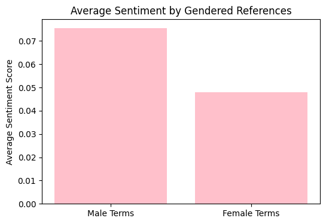

```python
# Detection Gendered Terms within Dataset

import matplotlib.pyplot as plt

groups = [
    "Male Terms",
    "Female Terms"
]

scores = [
    male_sentiment,
    female_sentiment
]

plt.figure(figsize=(6,4))

plt.bar(groups, scores, color="#ffc0cb")

plt.title("Average Sentiment by Gendered References")
plt.ylabel("Average Sentiment Score")

plt.show()
```

Due to limitations inherent within lexicon-based sentiment analyses, one should carefully consider their findings. They represent an incomplete interpretation of sarcasm, ideology or nuance (of context) as related to participants in online discourse. Therefore, it would be impossible to use the polarity of sentiment as a sole method to determine the supportive versus dismissive versus critical nature of the comments that were posted without additional reference to context (from which each comment could then be analysed).

# 8. Collocation and Context Analysis

With the use of collocation analysis, we are able to examine how gendered and therapy-related language is shown on the corpus by assessing linguistic context surrounding each time gendered terms or therapy-related terms appear. For these targets a sliding window of ±3 tokens is applied in the corpus. There is also a removal of NLTK stopwords and punctuation from the context window which results in a list of the common co-occuring terms that are sorted by frequency (i.e., words appearing within a window of ±3 tokens of each target). By doing this we are able to see an overview of the associated meanings given to these targets, which assists in identifying the themes in relation to the 2nd and 3rd Hypotheses. Collocation analysis in this example is particularly appropriate for identifying framing patterns that cannot be determined from sentiment alone.

## Collocation Analysis By Gender

While Sentiment Analysis gives you an overall assessment of an Emotional Tone, it does not provide a full representation of how Masculinity and Femininity are being constructed Linguistically within the Discourse. To overcome this limitation, a Collocation Analysis was conducted to identify terms that would Collocate with Male and Female Related Terms within an analysis of the conversation about Mental Health, Vulnerability and Therapy and show how the Gender-Related Identities are framed.

```python
import nltk
nltk.download('stopwords')
nltk.download('punkt')
```

```
True
```

```python
from collections import Counter
from nltk.corpus import stopwords
import string

stop_words = set(stopwords.words("english"))

def get_context_words(texts, target_terms, window_size=3):

    context_words = []

    for text in texts:

        words = nltk.word_tokenize(text)

        for i, word in enumerate(words):

            if word.lower() in target_terms:

                start = max(i - window_size, 0)
                end = min(i + window_size + 1, len(words))

                context = words[start:i] + words[i+1:end]

                cleaned_context = [

                    w.lower()

                    for w in context

                    if w.lower() not in stop_words
                    and w.lower() not in string.punctuation
                    and len(w) > 2
                ]

                context_words.extend(cleaned_context)

    return Counter(context_words)
```

```python
male_context = get_context_words(
    mh_df["clean_text"],
    male_terms
)

male_context.most_common(15)
```

```
[('toxic', 282),
 ('women', 187),
 ('like', 110),
 ('dont', 107),
 ('men', 103),
 ('help', 78),
 ('need', 77),
 ('want', 67),
 ('doesnt', 65),
 ('get', 63),
 ('young', 63),
 ('man', 54),
 ('many', 54),
 ('would', 51),
 ('think', 50)]
```

```python
female_context = get_context_words(
    mh_df["clean_text"],
    female_terms
)

female_context.most_common(15)
```

```
[('men', 166),
 ('want', 69),
 ('women', 61),
 ('dont', 61),
 ('like', 48),
 ('would', 44),
 ('get', 42),
 ('help', 41),
 ('think', 33),
 ('therapists', 33),
 ('man', 29),
 ('also', 29),
 ('doesnt', 28),
 ('therapist', 28),
 ('need', 27)]
```

```python
import pandas as pd

male_context_df = pd.DataFrame(
    male_context.most_common(10),
    columns=["Word", "Frequency"]
)

female_context_df = pd.DataFrame(
    female_context.most_common(10),
    columns=["Word", "Frequency"]
)

print("Male-related collocations")
display(male_context_df)

print("Female-related collocations")
display(female_context_df)
```

```
Male-related collocations
```

|  | Word | Frequency |
| --- | --- | --- |
| 0 | toxic | 282 |
| 1 | women | 187 |
| 2 | like | 110 |
| 3 | dont | 107 |
| 4 | men | 103 |
| 5 | help | 78 |
| 6 | need | 77 |
| 7 | want | 67 |
| 8 | doesnt | 65 |
| 9 | get | 63 |

```
Female-related collocations
```

|  | Word | Frequency |
| --- | --- | --- |
| 0 | men | 166 |
| 1 | want | 69 |
| 2 | women | 61 |
| 3 | dont | 61 |
| 4 | like | 48 |
| 5 | would | 44 |
| 6 | get | 42 |
| 7 | help | 41 |
| 8 | think | 33 |
| 9 | therapists | 33 |

A collocation analysis was performed in order to determine what the most common words were in relation to gender references within the corpus. This type of analysis reveals additional context and themes related to the male and female words that were used in online discussion.

The graphs below illustrate the most common contextual words associated with each gender group.

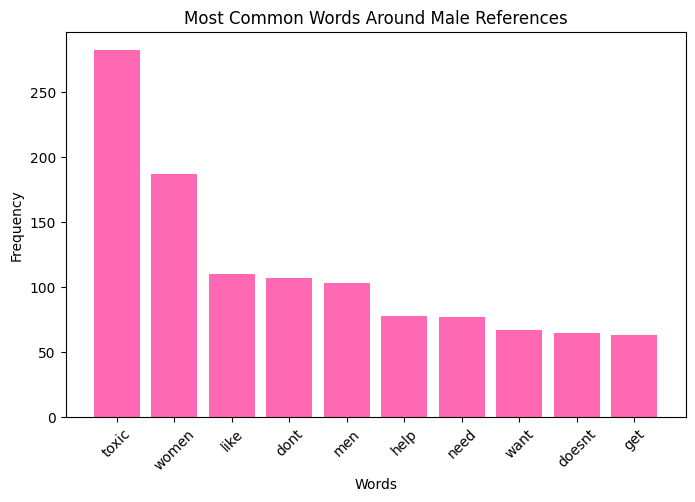

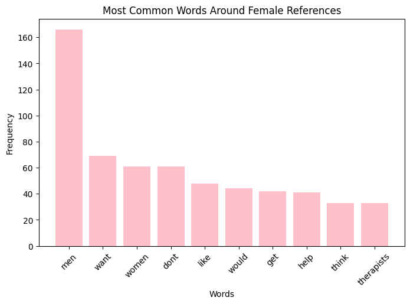

```python
import matplotlib.pyplot as plt

# Male collocations graph
plt.figure(figsize=(8,5))
plt.bar(
    male_context_df["Word"],
    male_context_df["Frequency"],
    color="#ff69b4"
)

plt.title("Most Common Words Around Male References")
plt.xlabel("Words")
plt.ylabel("Frequency")
plt.xticks(rotation=45)

plt.show()

# Female collocations graph
plt.figure(figsize=(8,5))
plt.bar(
    female_context_df["Word"],
    female_context_df["Frequency"],
    color="#ffc0cb"
)

plt.title("Most Common Words Around Female References")
plt.xlabel("Words")
plt.ylabel("Frequency")
plt.xticks(rotation=45)

plt.show()
```

# 9. Results

**HYPOTHESIS FINDINGS:**

*Hypothesis 4* is rejected. Contrary to expected results, therapy-related language which is present is 733 comments (41.1% of the sub-corpus) has appeared three times more frequently in comparison to self-improvement language with 244 comments (13.7% of the sub-corpus). This suggests that therapy functions as a contested topic in these spaces rather than one that is silenced.

# 10. Interpretation of Findings

These results are consistent with preexisting literature surrounding gender norms and the stigma surrounding mental health, especially concerning men's avoidance of vulnerability/emotional openness. These social norms may also assist in explaining why men's rate of therapy-seeking behaviour is lower than women. This analysis illustrates that Natural Language Processing (NLP) techniques are able to identify latent social patterns in the context of digital discussions about mental health and offer some insight into how gender can influence discourse regarding mental health.

VADER was developed based on general internet content; therefore, it does not perform well for text that includes sarcasm, irony, and “ideological dog whistling”, as is frequently the case in red pill-type content (e.g., the statement “just go to the gym bro” would be classified as neutral by VADER; however, functionally, that statement is being dismissive).

## 10.1 Therapy as contested discourse not silence

Perhaps the most theoretically relevant result from this analysis was that therapy is a frequent topic of discussion, and the H4s are often dismissed. Commenters who participate in these online spaces are actively and repeatedly engaging with the idea of therapy rather than either ignoring it or substituting other forms of self-help. This is consistent with research on online counter-discourse, which indicates that communities with strong ideological beliefs will produce considerable engagement around subjects with which they disagree (Ging, 2019). Because the number of instances of therapy identified in the data should not be perceived as endorsement, it may be more meaningful to appreciate these instances as an example of the ongoing ideological negotiation that continues to take place regarding the validity of therapy (e.g., getting support for oneself is often challenged, discussed or defended).

# 11. Conclusion, Limitations and Recommendations

## 11.1 Conclusion

This study utilized natural language processing (NLP) techniques to analyze 1785 comments related to mental health across 10 YouTube videos that promote red pill ideology. It employed keyword frequency analysis, VADER sentiment analysis, and collocation analysis to examine the framing and discussion of therapy, emotional vulnerability, and mental health support by online communities.

Thus, given the likelihood that men involved in red-pill-type communities are more likely than other men to find negative characteristics attributable to being therapeutic and/or emotionally vulnerable to be true, the implications of this study have repercussions for the manner in which men access services such as another type of therapy. This research demonstrates that a combination of natural-language processing (NLP) techniques (such as sentiment analysis, frequency analysis, and collocation analysis) have value in providing additional context for social relationships and ideologically based frames of reference in terms of masculine-oriented discourse about mental health in digital spaces.

## 11.2 Limitations

There are limitations to take into consideration when analyzing the results of this study. VADER is not able to assess emotion or sentiment for many of the instances that it was designed to evaluate. It does not do a good job determining whether a post contains sarcasm, irony, or ideological dog-whistles (often found in “red pill” discourse). This could cause the sentiment scores to not be a reliable, stand-alone measure of dismissiveness. The use of keywords to filter the corpus may lead to some selection bias. Comments that discuss mental health and do not contain the specified keywords would not be included in the study. The corpus contained only 10 videos, which may not represent the entire diversity of red pill-type material. YouTube comment sections contain bots and artificially amplified activity; as such, the frequencies may be skewed. The study examines language usage, not users — there is no way to know the demographics, genuineness, or mental health of individual commenters from the data alone.

## 11.3 Recommendations

There are many ways that future studies could address each of the limitations in this article. Latent Dirichlet Allocation (LDA) topic modelling would allow for unsupervised identification of thematic clusters beyond the keyword categories that were defined in this study and may reveal new patterns of discourse that were not predicted in the initial hypothesis. Manual coding by trained reviewers on a sample of random comments would validate the findings regarding sentiment and collocations and help produce an industry-specific sentiment lexicon that is better aligned with red pill discourse. Longitudinal data (i.e., looking at the same channels over several years) could be examined to see if there have been changes in therapy discourse across these platforms as a result of increased public discourse surrounding men's mental health. Finally, a cross-platform comparison (i.e., comparing comments from Reddit and TikTok) would test whether these patterns generalise to other platforms in addition to YouTube.

# References

Addis, M. E., & Mahalik, J. R. (2003). Men, masculinity, and the contexts of help seeking. American Psychologist, 58(1), 5–14.

Botto, M., & Gottzén, L. (2023). Swallowing and spitting out the red pill: young men, vulnerability, and radicalization pathways in the manosphere. *Gender and Education*, 35. https://doi.org/10.1080/09589236.2023.2260318

Connell, R. W. (1995). Masculinities. Cambridge: Polity Press.

Ging, D. (2019). Alphas, betas, and incels: Theorizing the masculinities of the manosphere. Men and Masculinities, 22(4), 638–657.

Hutto, C. J., & Gilbert, E. (2014). VADER: A parsimonious rule-based model for sentiment analysis of social media text. Proceedings of the Eighth International Conference on Weblogs and Social Media (ICWSM-14).

Lilly, M. (2022). Hegemonic masculinities in the 'Manosphere': A thematic analysis of beliefs about men and women on The Red Pill and Incel. *Analyses of Social Issues and Public Policy*, 22, 602–625. https://doi.org/10.1111/asap.12308

Möller-Leimkühler, A. M. (2002). Barriers to help-seeking by men: A review of sociocultural and clinical literature with particular reference to depression. Journal of Affective Disorders, 71(1–3), 1–9.

UN Women. (2026). Glossary: The manosphere. https://www.unwomen.org/en/articles/glossary/glossary-the-manosphere

Van Valkenburgh, S. P. (2021). Digesting the red pill: Masculinity and neoliberalism in the manosphere. *Men and Masculinities*, 24(1), 84–103.

Seidler, Z. E., Dawes, A. J., Rice, S. M., Oliffe, J. L., & Dhillon, H. M. (2016). The role of masculinity in men's help-seeking for depression: A systematic review. Clinical Psychology Review, 49, 106–118.

```python
print("Mental health comments:", len(mh_df))
print("Therapy comments:", therapy_comments)
print("Self-improvement comments:", self_comments)
```

```
Mental health comments: 1785
Therapy comments: 733
Self-improvement comments: 244
```